# Lecture2

Parthsarthy Nandi

2022-12-02

```r
source("http://www.openintro.org/stat/data/cdc.R")
```

### NOW ON YOUR OWN….

1. Make a scatterplot of weight versus desired weight. Describe the relationship between these two variables.

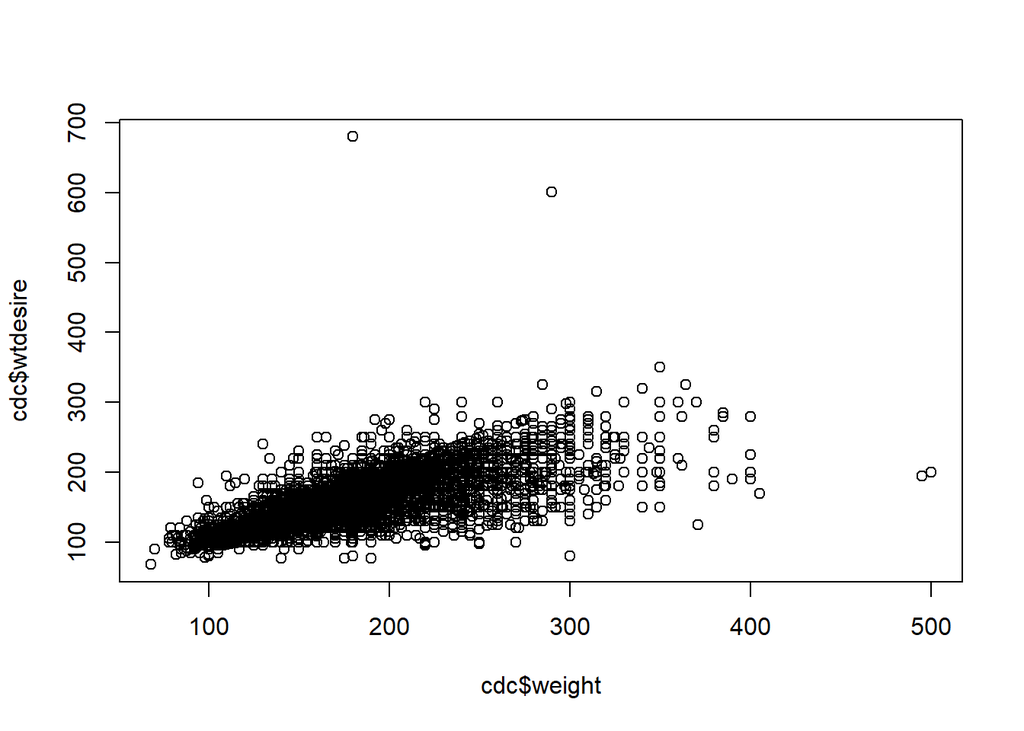

[output not shown]

```r
plot( cdc$weight , cdc$wtdesire  )
```

1. Let’s consider a new variable: the difference between desired weight (wtdesire) and current weight (weight).
2. Create this new variable by subtracting the two columns in the data frame and assigning them to a new object called wdiff.

```r
wdiff = cdc$wtdesire - cdc$weight
head(wdiff,n=10)
```

```
##  [1]   0 -10   0  -8 -20   0  -9 -10 -20 -10
```

1. What type of data is wdiff? If an observation wdiff is 0, what does this mean about the person’s weight and desired weight.

```r
class(wdiff)
```

```
## [1] "integer"
```

```
If a persons weight is 0 it means the person's weight and desired weight is same.
```

1. What if wdiff is positive or negative? If negative person has to lose weight and if Positive he has to gain weight.
2. Describe the distribution of wdiff in terms of its center, shape, and spread, including any plots you use.

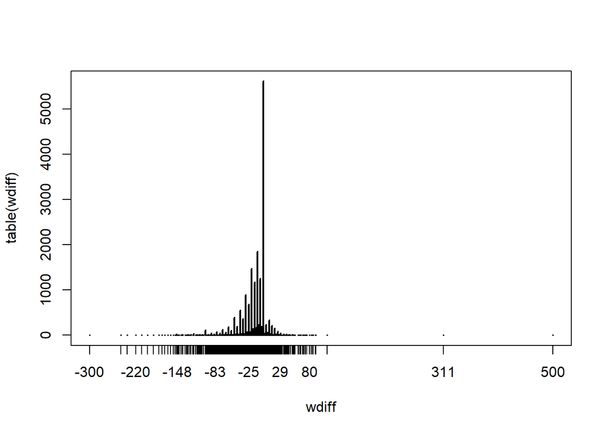

```r
#table(wdiff)
plot(table(wdiff))
```

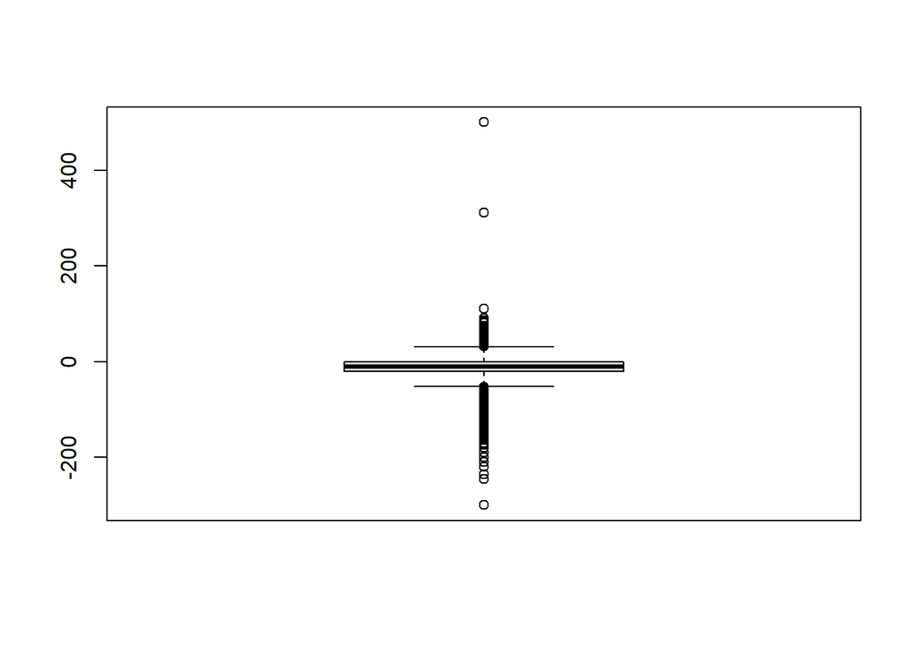

```r
boxplot(wdiff)
```

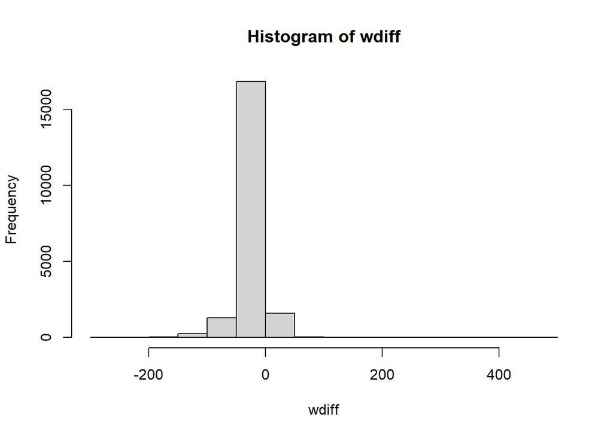

```r
hist(wdiff)
```

```r
summary(wdiff)
```

```
##    Min. 1st Qu.  Median    Mean 3rd Qu.    Max.
## -300.00  -21.00  -10.00  -14.59    0.00  500.00
```

[output not shown]

```r
cdc_male = subset(wdiff,cdc$gender == 'm')
cdc_female = subset(wdiff,cdc$gender == 'f')
summary(cdc_male)
```

```
##    Min. 1st Qu.  Median    Mean 3rd Qu.    Max.
## -300.00  -20.00   -5.00  -10.71    0.00  500.00
```

```r
summary(cdc_female)
```

```
##    Min. 1st Qu.  Median    Mean 3rd Qu.    Max.
## -300.00  -27.00  -10.00  -18.15    0.00   83.00
```

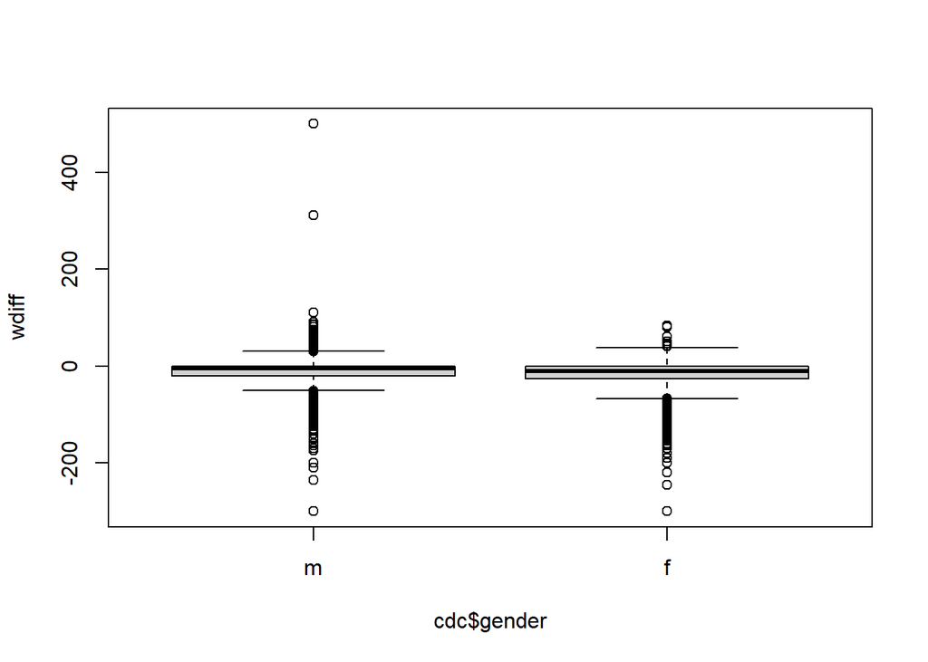

```r
boxplot(wdiff ~ cdc$gender)
```

#. Now it’s time to get creative. Find the mean and standard deviation of weight and determine #. what proportion of the weights are within one standard deviation of the mean.

```r
cdc_mean <- mean(cdc$weight)
cdc_sd <- sd(cdc$weight)
cdc_one_sd <- subset(cdc, cdc$weight>(cdc_mean-cdc_sd) & cdc$weight<(cdc_mean+cdc_sd))
nrow(cdc_one_sd)/nrow(cdc)*100
```

```
## [1] 70.76
```

```
Therefore 70.76 % are within one standard deviation.
```